# 05_Statistical_analyses

## Analyses for autism manuscript

Author: Filip Ottosson faot@ssi.dk

2023-07-18

This notebook includes all statistical analyses for the neonatal cohort in "Unraveling the metabolomic architecture of autism in a large Danish population-based cohort"

## Import packages

```r
suppressPackageStartupMessages({
library(dplyr)
library(tidyverse)
library(ggsci)
library(cowplot)
library(ppcor)
library(reshape2)
library(lubridate)
library(ggrepel)
library(data.table)
})
```

# Import Metabolites and Metadata

**Metabolite data** is imported from two different files:

**metabolites**: includes measurments for metabolites that were present in at least 75 % of the individuals in the dataset and are expressed as continuous variables

```r
metabolites <- read.csv(".../ft_blankfilled_normalized_continuous.csv",
                       sep = ',', check.names = F, row.names = 1)

metabolites_binary <- read.csv(".../ft_blankfilled_categorical.csv",
                       sep = ',', check.names = F, row.names = 1)

metadata1 <- read.csv(".../metadata_combined_cohort_1.txt",
                        sep = '\t', check.names = F, row.names = 1)

metadata2 <- read.csv(".../metadata_combined_cohort_2.txt",
                        sep = '\t', check.names = F, row.names = 1)
```

```r
metadata <- rbind(metadata1,metadata2)

metadata <- subset(metadata,sample_type="exp_sample")
```

```r
dim(metadata)
```

1. 1740

2. 42

**Genetic risk scores and genetic principal components are imported and merged with the metadata**

```r
grs <- read.csv(".../ASD_prs_internal",
               sep = '\t')
colnames(grs)[c(1,5)] <- c("pid","grs")

pcs <- read.table(".../ASD2015_pca2_ell_dk-dim3_8_8_8.menv.mds",header = TRUE)
pcs <- pcs %>% dplyr::select(FID,C1,C2,C3,C4,C5,C6)
colnames(pcs)[1] <- "pid"

dim(grs)
grs <- merge(grs,pcs,by="pid",all.x = TRUE)
```

1. 134676

2. 5

```r
dim(grs)
dim(pcs)
```

1. 134676

2. 11

1. 58948

2. 7

```r
dim(grs[!is.na(grs$C1),])
```

1. 58970

2. 11

```r
metadata <- merge(metadata,grs,by="pid")
```

```r
dim(metadata)
```

1. 1730

2. 52

```r
metabolites <- metabolites[,-c(1:2)]
```

```r
metabolites_binary[metabolites_binary>0]<-1
metabolites_binary<- metabolites_binary[colSums(metabolites_binary)>(nrow(metabolites_binary)*0.2)]
```

```r
metabolites_binary$filename_mzml <- rownames(metabolites_binary)
metabolites_binary <- relocate(.data=metabolites_binary,filename_mzml)
```

```r
metabolites["filename_mzml"] <- rownames(metabolites)
metabolites <- relocate(.data=metabolites,filename_mzml)
```

**Merging metabolites and metadata**

```r
start <- which(names(metadata)=="class_cat")+1 #Indicating the first metabolite column in the dataset
Data <- merge(metadata,metabolites,by="filename_mzml")

Data <- merge(Data,metabolites_binary,by="filename_mzml")
```

There are ten participants that are missing, i.e do not have metadata

```r
Cases <- subset(Data,class==1)
Controls <- subset(Data,class==0)
```

```r
dim(Cases)
dim(Controls)
```

1. 747

2. 919

1. 741

2. 919

Make sure that all cases have a control and that there are no controls without matching case

```r
Cases <- Cases[Cases$pair_id %in% Controls$pair_id,]
```

```r
Controls <- Controls[Controls$pair_id %in% Cases$pair_id,]
```

```r
dim(Cases)
dim(Controls)
```

1. 739

2. 919

1. 739

2. 919

```r
Data <- rbind(Cases,Controls)
```

```r
Data["fam_hist"] <- ifelse(Data$date_psych_m!="",1,ifelse(Data$date_psych_f!="",1,0))
Data$caesarean <- ifelse(Data$caesarean=="",0,1)
sum(ifelse(Data$date_psych_m=="",0,1)+ifelse(Data$date_psych_f=="",0,1)==0)
sum(ifelse(Data$date_psych_m=="",0,1)+ifelse(Data$date_psych_f=="",0,1)==1)
sum(ifelse(Data$date_psych_m=="",0,1)+ifelse(Data$date_psych_f=="",0,1)==2)
```

1118

304

56

```r
Data <- relocate(.data=Data,fam_hist,.after=sample)
start <- which(names(Data)=="injection.order")+1
```

**Import annotations**

```r
annotations <- read.csv(".../annotations_curated.csv")
annotations <- annotations %>% dplyr::select(id=metID,annotation=Metabolite,Class)
```

# Logistic regression

Logistic regression models are used to find associations between metabolites and autism. Three different models (per metabolite) are used:

**Model 1**: Autism ~ Metabolite + season of birth + age at sampling + year of birth

**Model 2**: Autism ~ Metabolite + season of birth + age at sampling + year of birth + family history of psychiatric disorders

**Model 3**: Autism ~ Metabolite + season of birth + age at sampling + year of birth + family history of psychiatric disorders + genetic risk score for autism + Principal component 1-6

```r
X <- Data[start:ncol(Data)]
logreg=NULL
a <- start:ncol(Data)
for (i in 1:length(a)){
logreg[[i]] <- glm(class~scale(Data[,a[i]])+season_birth+age_at_sampling+gest+as.factor(year)
                   ,data=Data,family="binomial")
    }
```

```r
output_logreg <- cbind.data.frame(names(X))
colnames(output_logreg)[1] <- "Metabolite"
output_logreg["OR_logreg"]  <- sapply(1:length(a),function(n){exp(coef(summary(logreg[[n]]))[2,1])})
output_logreg["logOR_logreg"]  <- sapply(1:length(a),function(n){coef(summary(logreg[[n]]))[2,1]})
output_logreg["p_logreg"] <- sapply(1:length(a),function(n){coef(summary(logreg[[n]]))[2,4]})
output_logreg["CI_low_logreg"] <- sapply(1:length(a),function(n){exp(confint.default(logreg[[n]]))[2]})
output_logreg["CI_high_logreg"] <- sapply(1:length(a),function(n){exp(confint.default(logreg[[n]])[12])})
output_logreg["p_fdr_logreg"] <- p.adjust(output_logreg$p_logreg,method="fdr")
output_logreg["p_bonf_logreg"] <- p.adjust(output_logreg$p_logreg,method="bonferroni")
output_logreg["significant_logreg"] <- ifelse(output_logreg$p_fdr<0.05,"Significant","Nonsignificant")
output_logreg <- merge(output_logreg,annotations,by.x="Metabolite",by.y="id",all.x=TRUE)
output_logreg["significant_nominal"] <- ifelse(output_logreg$p_logreg>0.05,"Nonsignificant",
                                               ifelse(output_logreg$p_fdr_logreg<0.05,"Significant",
                                                      "Nominally significant"))
```

```r
output_logreg %>% arrange(p_logreg) %>% slice_head(n=20)
```

A data.frame: 20 × 12

| Metabolite <chr> | OR_logreg <dbl> | logOR_logreg <dbl> | p_logreg <dbl> | CI_low_logreg <dbl> | CI_high_logreg <dbl> | p_fdr_logreg <dbl> | p_bonf_logreg <dbl> | significant_logreg <chr> | annotation <chr> | Class <chr> | significant_nominal <chr> |
| --- | --- | --- | --- | --- | --- | --- | --- | --- | --- | --- | --- |
| 11694 | 1.2823329 | 0.2486810 | 3.826283e-06 | 1.1539555 | 0.6558149 | 0.003309735 | 0.003309735 | Significant | Cyclo(Leu-Pro) | Amino acids and derivatives | Significant |
| 3376 | 1.2392959 | 0.2145434 | 7.117148e-05 | 1.1148133 | 0.6881084 | 0.030781666 | 0.061563331 | Significant | 5-aminovaleric acid betaine | Acyl carnitines | Significant |
| 4169 | 1.2207904 | 0.1994985 | 3.489152e-04 | 1.0943441 | 0.6866562 | 0.087064312 | 0.301811654 | Nonsignificant | NA | NA | Nominally significant |
| 8577 | 1.2073925 | 0.1884631 | 4.026095e-04 | 1.0877051 | 0.6895277 | 0.087064312 | 0.348257249 | Nonsignificant | NA | NA | Nominally significant |
| 1824 | 0.8346169 | -0.1807825 | 6.344094e-04 | 0.7523947 | 0.6936390 | 0.092489185 | 0.548764140 | Nonsignificant | NA | NA | Nominally significant |
| 2330 | 1.2136867 | 0.1936626 | 6.415435e-04 | 1.0859581 | 0.6970726 | 0.092489185 | 0.554935109 | Nonsignificant | Alanine | Amino acids and derivatives | Nominally significant |
| 10017 | 1.1886978 | 0.1728584 | 1.227301e-03 | 1.0704164 | 0.6674995 | 0.120351726 | 1.000000000 | Nonsignificant | Cyclo(Pro-Val) | Amino acids and derivatives | Nominally significant |
| 3153 | 1.1896314 | 0.1736435 | 1.253041e-03 | 1.0705399 | 0.7055479 | 0.120351726 | 1.000000000 | Nonsignificant | NA | NA | Nominally significant |
| 4187 | 1.1931062 | 0.1765602 | 1.319694e-03 | 1.0712345 | 0.6268664 | 0.120351726 | 1.000000000 | Nonsignificant |  | Straight chain fatty acids | Nominally significant |
| 1791 | 1.2018136 | 0.1838317 | 1.391349e-03 | 1.0737009 | 0.7060189 | 0.120351726 | 1.000000000 | Nonsignificant | NA | NA | Nominally significant |
| 3414 | 1.1795666 | 0.1651471 | 2.211618e-03 | 1.0611750 | 0.6955981 | 0.168461153 | 1.000000000 | Nonsignificant | Aminoadipic acid | Amino acids and derivatives | Nominally significant |
| 5986 | 1.1844350 | 0.1692659 | 2.337033e-03 | 1.0621210 | 0.7672574 | 0.168461153 | 1.000000000 | Nonsignificant | NA | NA | Nominally significant |
| 5842 | 1.1788992 | 0.1645811 | 2.863307e-03 | 1.0580307 | 0.7633840 | 0.173416635 | 1.000000000 | Nonsignificant | NA | NA | Nominally significant |
| 17710 | 1.1730046 | 0.1595685 | 3.348767e-03 | 1.0543932 | 0.7324102 | 0.173416635 | 1.000000000 | Nonsignificant | NA | NA | Nominally significant |
| 5875 | 0.8572520 | -0.1540234 | 3.575801e-03 | 0.7728709 | 0.6933802 | 0.173416635 | 1.000000000 | Nonsignificant | NA | NA | Nominally significant |
| 4450 | 1.1694101 | 0.1564995 | 3.653783e-03 | 1.0522909 | 0.6982889 | 0.173416635 | 1.000000000 | Nonsignificant | NA | NA | Nominally significant |
| 5311 | 1.1802520 | 0.1657280 | 3.702551e-03 | 1.0552898 | 0.7294638 | 0.173416635 | 1.000000000 | Nonsignificant | NA | NA | Nominally significant |
| 4676 | 1.1835833 | 0.1685465 | 3.896065e-03 | 1.0555901 | 0.6913724 | 0.173416635 | 1.000000000 | Nonsignificant |  | Amino acids and derivatives | Nominally significant |
| 2316 | 1.1769262 | 0.1629061 | 3.983962e-03 | 1.0533963 | 0.6984285 | 0.173416635 | 1.000000000 | Nonsignificant | Creatine | Amino acids and derivatives | Nominally significant |
| 4448 | 1.1673067 | 0.1546992 | 4.009633e-03 | 1.0505614 | 0.6957513 | 0.173416635 | 1.000000000 | Nonsignificant | Uric acid | Xanthines | Nominally significant |

```r
logreg=NULL
a <- start:ncol(Data)
for (i in 1:length(a)){
logreg[[i]] <- glm(class~scale(Data[,a[i]])+season_birth+age_at_sampling+gest+as.factor(year)+
                   fam_hist
                   ,data=Data,family="binomial")
    }
```

```r
output_logreg2 <- cbind.data.frame(names(X))
colnames(output_logreg2)[1] <- "Metabolite"
output_logreg2["OR_logreg"]  <- sapply(1:length(a),function(n){exp(coef(summary(logreg[[n]]))[2,1])})
output_logreg2["logOR_logreg"]  <- sapply(1:length(a),function(n){coef(summary(logreg[[n]]))[2,1]})
output_logreg2["p_logreg"] <- sapply(1:length(a),function(n){coef(summary(logreg[[n]]))[2,4]})
output_logreg2["CI_low_logreg"] <- sapply(1:length(a),function(n){exp(confint.default(logreg[[n]]))[2]})
output_logreg2["CI_high_logreg"] <- sapply(1:length(a),function(n){exp(confint.default(logreg[[n]])[12])})
output_logreg2["p_fdr_logreg"] <- p.adjust(output_logreg2$p_logreg,method="fdr")
output_logreg2["p_bonf_logreg"] <- p.adjust(output_logreg2$p_logreg,method="bonferroni")
output_logreg2["significant_logreg"] <- ifelse(output_logreg2$p_fdr<0.05,"Significant","Nonsignificant")
output_logreg2 <- merge(output_logreg2,annotations,by.x="Metabolite",by.y="id",all.x=TRUE)
output_logreg2["significant_nominal"] <- ifelse(output_logreg2$p_logreg>0.05,"Nonsignificant",
                                              ifelse(output_logreg2$p_fdr_logreg<0.05,"Significant",
                                                     "Nominally significant"))
```

```r
output_logreg2 %>% arrange(p_logreg) %>% slice_head(n=5)
```

A data.frame: 5 × 12

| Metabolite <chr> | OR_logreg <dbl> | logOR_logreg <dbl> | p_logreg <dbl> | CI_low_logreg <dbl> | CI_high_logreg <dbl> | p_fdr_logreg <dbl> | p_bonf_logreg <dbl> | significant_logreg <chr> | annotation <chr> | Class <chr> | significant_nominal <chr> |
| --- | --- | --- | --- | --- | --- | --- | --- | --- | --- | --- | --- |
| 11694 | 1.266799 | 0.2364933 | 1.317279e-05 | 1.138958 | 0.6518216 | 0.01139446 | 0.01139446 | Significant | Cyclo(Leu-Pro) | Amino acids and derivatives | Significant |
| 4169 | 1.226489 | 0.2041553 | 2.769358e-04 | 1.098676 | 0.6794375 | 0.11977473 | 0.23954946 | Nonsignificant | NA | NA | Nominally significant |
| 3376 | 1.206846 | 0.1880104 | 5.769467e-04 | 1.084327 | 0.6829408 | 0.16635297 | 0.49905891 | Nonsignificant | 5-aminovaleric acid betaine | Acyl carnitines | Nominally significant |
| 8577 | 1.192720 | 0.1762363 | 1.067336e-03 | 1.073231 | 0.6831143 | 0.21047113 | 0.92324571 | Nonsignificant | NA | NA | Nominally significant |
| 4187 | 1.196958 | 0.1797831 | 1.216596e-03 | 1.073429 | 0.6199420 | 0.21047113 | 1.00000000 | Nonsignificant |  | Straight chain fatty acids | Nominally significant |

**For genetic model adjusting for genetic risk score, individuals with relatives in iPSCYCH2015 are removed, in order to compute genetic principal components**

Percentage of individuals that are excluded due to being ancestry outliers:

```r
(nrow(Data)-sum(!is.na(Data$C1)))/nrow(Data)
```

0.166441136671177

```r
logreg=NULL
a <- start:ncol(Data)
for (i in 1:length(a)){
logreg[[i]] <- glm(class~scale(Data[,a[i]])+season_birth+age_at_sampling+gest+as.factor(year)+
                   fam_hist+grs+C1+C2+C3+C4+C5+C6
                   ,data=Data,family="binomial",subset=!is.na(C1))
    }
```

```r
output_logreg3 <- cbind.data.frame(names(X))
colnames(output_logreg3)[1] <- "Metabolite"
output_logreg3["OR_logreg"]  <- sapply(1:length(a),function(n){exp(coef(summary(logreg[[n]]))[2,1])})
output_logreg3["logOR_logreg"]  <- sapply(1:length(a),function(n){coef(summary(logreg[[n]]))[2,1]})
output_logreg3["p_logreg"] <- sapply(1:length(a),function(n){coef(summary(logreg[[n]]))[2,4]})
output_logreg3["CI_low_logreg"] <- sapply(1:length(a),function(n){exp(confint.default(logreg[[n]]))[2]})
output_logreg3["CI_high_logreg"] <- sapply(1:length(a),function(n){exp(confint.default(logreg[[n]])[12])})
output_logreg3["p_fdr_logreg"] <- p.adjust(output_logreg3$p_logreg,method="fdr")
output_logreg3["p_bonf_logreg"] <- p.adjust(output_logreg3$p_logreg,method="bonferroni")
output_logreg3["significant_logreg"] <- ifelse(output_logreg3$p_fdr<0.05,"Significant","Nonsignificant")
output_logreg3 <- merge(output_logreg3,annotations,by.x="Metabolite",by.y="id",all.x=TRUE)
output_logreg3["significant_nominal"] <- ifelse(output_logreg3$p_logreg>0.05,"Nonsignificant",
                                              ifelse(output_logreg3$p_fdr_logreg<0.05,"Significant",
                                                     "Nominally significant"))
```

```r
output_logreg3 %>% arrange(p_logreg) %>% slice_head(n=5)
```

A data.frame: 5 × 12

| Metabolite <chr> | OR_logreg <dbl> | logOR_logreg <dbl> | p_logreg <dbl> | CI_low_logreg <dbl> | CI_high_logreg <dbl> | p_fdr_logreg <dbl> | p_bonf_logreg <dbl> | significant_logreg <chr> | annotation <chr> | Class <chr> | significant_nominal <chr> |
| --- | --- | --- | --- | --- | --- | --- | --- | --- | --- | --- | --- |
| 11694 | 1.2353362 | 0.2113432 | 0.000486979 | 1.0970007 | 0.6012114 | 0.3522133 | 0.4212369 | Nonsignificant | Cyclo(Leu-Pro) | Amino acids and derivatives | Nominally significant |
| 1824 | 0.8179444 | -0.2009609 | 0.000827338 | 0.7270463 | 0.6308035 | 0.3522133 | 0.7156474 | Nonsignificant | NA | NA | Nominally significant |
| 1791 | 1.2366897 | 0.2124382 | 0.001534402 | 1.0843838 | 0.6331098 | 0.3522133 | 1.0000000 | Nonsignificant | NA | NA | Nominally significant |
| 3376 | 1.2131315 | 0.1932051 | 0.001767710 | 1.0747580 | 0.6142397 | 0.3522133 | 1.0000000 | Nonsignificant | 5-aminovaleric acid betaine | Acyl carnitines | Nominally significant |
| 17058 | 0.8312050 | -0.1848788 | 0.002246016 | 0.7382552 | 0.5688439 | 0.3522133 | 1.0000000 | Nonsignificant | NA | NA | Nominally significant |

**Volcano plot - Logistic regression results model 1**

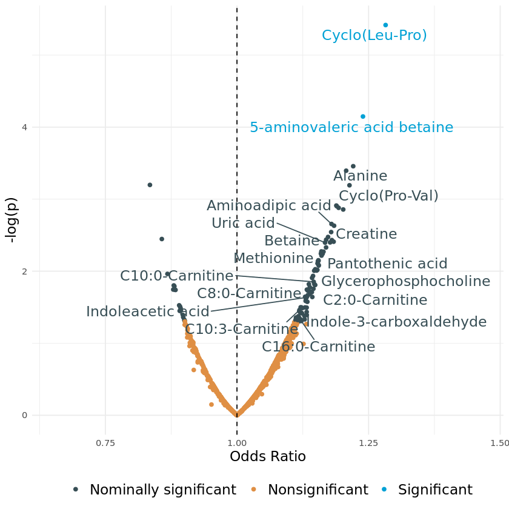

```r
p_logreg_nominal <- ggplot(output_logreg,aes(x=OR_logreg,y=-log(p_logreg,base=10),color=significant_nominal))+
geom_point()+
theme_minimal()+
scale_color_jama()+
geom_vline(xintercept = 1,linetype="dashed")+
scale_x_continuous(expand=expansion(mult=0.5))+
ylab("-log(p)")+
xlab("Odds Ratio")+
theme(legend.title = element_blank(),
     legend.position="bottom",legend.text=element_text(size=14),axis.title=element_text(size=14))+
geom_text_repel(data=subset(output_logreg,significant_nominal!="Nonsignificant" & annotation!=""),
                  aes(label=annotation),size=5,show.legend = FALSE,max.overlaps = Inf, force=1,force_pull=0,
                 min.segment.length = 1,max.time=20)

p_logreg_nominal
```

# 5-AVAB & cLP

Two metabolites were significantly associated with autism in Model 1, after taking multiple tests into consideration. These are investigated in more detail below.

First, are the metabolites cLP and 5-AVAB independently associated with autism?

```r
summary(glm(class~scale(Data$"3376")+scale(Data$"11694")+season_birth+gest+age_at_sampling+as.factor(year),
            data=Data,family="binomial"))
```

```
Call:
glm(formula = class ~ scale(Data$"3376") + scale(Data$"11694") +
    season_birth + gest + age_at_sampling + as.factor(year),
    family = "binomial", data = Data)

Deviance Residuals:
     Min        1Q    Median        3Q       Max
-1.59331  -1.12961  -0.08893   1.17196   1.46553

Coefficients:
                     Estimate Std. Error z value Pr(>|z|)
(Intercept)          0.025286   1.725150   0.015 0.988306
scale(Data$"3376")   0.193081   0.054599   3.536 0.000406 ***
scale(Data$"11694")  0.230345   0.054239   4.247 2.17e-05 ***
season_birthspring  -0.042498   0.147745  -0.288 0.773620
season_birthsummer   0.025286   0.146196   0.173 0.862684
season_birthwinter  -0.006729   0.150629  -0.045 0.964368
gest                -0.001093   0.006048  -0.181 0.856645
age_at_sampling      0.059038   0.046552   1.268 0.204717
as.factor(year)2004 -0.022427   0.186808  -0.120 0.904438
as.factor(year)2005 -0.077929   0.180055  -0.433 0.665157
as.factor(year)2006 -0.097481   0.194927  -0.500 0.617013
as.factor(year)2007 -0.067361   0.188792  -0.357 0.721244
as.factor(year)2008 -0.062310   0.187214  -0.333 0.739263
---
Signif. codes:  0 ‘***’ 0.001 ‘**’ 0.01 ‘*’ 0.05 ‘.’ 0.1 ‘ ’ 1

(Dispersion parameter for binomial family taken to be 1)

    Null deviance: 2048.9  on 1477  degrees of freedom
Residual deviance: 2014.2  on 1465  degrees of freedom
AIC: 2040.2

Number of Fisher Scoring iterations: 4
```

Is 5-AVAB associated with autism after adjusting for structurally simimlar acyl carnitines?

```r
output_5avab_mod1 <- summary(glm(class~scale(Data$"3376")+season_birth+gest+age_at_sampling+as.factor(year),
            data=Data,family="binomial"))

output_5avab_ac_corr <- summary(glm(class~scale(Data$"3376")+season_birth+gest+age_at_sampling+as.factor(year)+
            Data$"14569"+Data$"21061"+Data$"3942",data=Data,family="binomial"))
```

```r
exp(output_5avab_mod1$coefficients[2,1])
output_5avab_mod1$coefficients[2,4]
exp(output_5avab_ac_corr$coefficients[2,1])
output_5avab_ac_corr$coefficients[2,4]
```

1.2392959453232

7.11714810039592e-05

1.2251990855583

0.00125959428135183

Is cLP associated with autism after adjusting for structurally simimlar cyclo(proline-valine)?

```r
output_cLP_mod1 <- summary(glm(class~scale(Data$"11694")+season_birth+gest+age_at_sampling+as.factor(year),
            data=Data,family="binomial"))

output_cLP_pep_corr<- summary(glm(class~scale(Data$"11694")+season_birth+gest+age_at_sampling+as.factor(year)+
            Data$"10017",
            data=Data,family="binomial"))
```

```r
exp(output_cLP_mod1$coefficients[2,1])
output_cLP_mod1$coefficients[2,4]
exp(output_cLP_pep_corr$coefficients[2,1])
output_cLP_pep_corr$coefficients[2,4]
```

1.28233287284937

3.82628308837949e-06

1.30195741860021

0.000872551448868974

```r
summary(glm(class~scale(Data$"3376")+scale(Data$"3942")+scale(Data$"21061")+scale(Data$"14569")+scale(Data$"14033")+
            scale(Data$"16455")+season_birth+gest+age_at_sampling+as.factor(year),
            data=Data,family="binomial"))
```

```
Call:
glm(formula = class ~ scale(Data$"3376") + scale(Data$"3942") +
    scale(Data$"21061") + scale(Data$"14569") + scale(Data$"14033") +
    scale(Data$"16455") + season_birth + gest + age_at_sampling +
    as.factor(year), family = "binomial", data = Data)

Deviance Residuals:
    Min       1Q   Median       3Q      Max
-1.6573  -1.1569  -0.1507   1.1754   1.4550

Coefficients:
                     Estimate Std. Error z value Pr(>|z|)
(Intercept)          0.567185   1.711815   0.331   0.7404
scale(Data$"3376")   0.200169   0.063050   3.175   0.0015 **
scale(Data$"3942")  -0.030217   0.071255  -0.424   0.6715
scale(Data$"21061")  0.063429   0.058353   1.087   0.2770
scale(Data$"14569")  0.024965   0.106286   0.235   0.8143
scale(Data$"14033")  0.085247   0.054159   1.574   0.1155
scale(Data$"16455")  0.075211   0.105955   0.710   0.4778
season_birthspring  -0.067006   0.147362  -0.455   0.6493
season_birthsummer   0.030336   0.146226   0.207   0.8357
season_birthwinter  -0.019532   0.150885  -0.129   0.8970
gest                -0.002759   0.006037  -0.457   0.6477
age_at_sampling      0.039177   0.049991   0.784   0.4332
as.factor(year)2004  0.002232   0.187744   0.012   0.9905
as.factor(year)2005 -0.025132   0.181213  -0.139   0.8897
as.factor(year)2006 -0.046066   0.195124  -0.236   0.8134
as.factor(year)2007  0.008024   0.189571   0.042   0.9662
as.factor(year)2008  0.012305   0.187181   0.066   0.9476
---
Signif. codes:  0 ‘***’ 0.001 ‘**’ 0.01 ‘*’ 0.05 ‘.’ 0.1 ‘ ’ 1

(Dispersion parameter for binomial family taken to be 1)

    Null deviance: 2048.9  on 1477  degrees of freedom
Residual deviance: 2024.5  on 1461  degrees of freedom
AIC: 2058.5

Number of Fisher Scoring iterations: 4
```

# Stratify on time-to-disease

We investigate whether metabolites have similar associations with autism indepently of the age of diagnosis. Stratified analyses are performed with a cut-off at age 6.

```r
Data <- Data %>% add_column(fu_aut=(difftime(dmy(Data$date_childhood_autism),dmy(Data$fdato),units = "days")/365),.before = start)
cases_late <- subset(Data,class==1 & fu_aut>6)
cases_early <- subset(Data,class==1 & fu_aut<6)
```

```r
dim(cases_late)
dim(cases_early)
```

1. 348

2. 921

1. 391

2. 921

```r
controls <- subset(Data,class==0)
controls_late <- controls[controls$pair_id %in% cases_late$pair_id,]
controls_early <- controls[controls$pair_id %in% cases_early$pair_id,]
```

```r
length(unique(Data$pair_id))
```

739

```r
dim(cases_late)
dim(cases_early)
dim(controls_late)
dim(controls_early)
identical(cases_late$pair_id,controls_late$pair_id)
identical(cases_early$pair_id,controls_early$pair_id)
```

1. 348

2. 921

1. 391

2. 921

1. 348

2. 921

1. 391

2. 921

TRUE

TRUE

```r
Data_early <- rbind(cases_early,controls_early)
Data_late <- rbind(cases_late,controls_late)
```

```r
start <- which(names(Data)=="fu_aut")+1
a <- start:ncol(Data_early)
for (i in 1:length(a)){
logreg[[i]] <- glm(class~scale(Data_early[,a[i]])+season_birth+year+age_at_sampling_days,data=Data_early,family="binomial")
    }
```

```r
output_logreg_early <- cbind.data.frame(names(X))
colnames(output_logreg_early) <- "Metabolite"

output_logreg_early["OR_early"]  <- sapply(1:length(a),function(n){exp(coef(summary(logreg[[n]]))[2,1])})
output_logreg_early["p_early"] <- sapply(1:length(a),function(n){coef(summary(logreg[[n]]))[2,4]})
output_logreg_early["CI_low_logreg_early"] <- sapply(1:length(a),function(n){exp(confint.default(logreg[[n]]))[2]})
output_logreg_early["CI_high_logreg_early"] <- sapply(1:length(a),function(n){exp(confint.default(logreg[[n]])[12])})
output_logreg_early["p_early_fdr"] <- p.adjust(output_logreg_early$p_early,method="fdr")
```

```r
output_logreg_early %>% arrange(p_early) %>% slice_head(n=5)
```

A data.frame: 5 × 6

| Metabolite <chr> | OR_early <dbl> | p_early <dbl> | CI_low_logreg_early <dbl> | CI_high_logreg_early <dbl> | p_early_fdr <dbl> |
| --- | --- | --- | --- | --- | --- |
| 3376 | 1.378749 | 2.148937e-05 | 1.188889 | 1.569277 | 0.01858830 |
| 8577 | 1.349524 | 6.161231e-05 | 1.165460 | 1.598359 | 0.02664732 |
| 5311 | 1.292412 | 1.163464e-03 | 1.107060 | 1.376042 | 0.21172387 |
| 11694 | 1.267729 | 1.196055e-03 | 1.098245 | 1.593007 | 0.21172387 |
| 1791 | 1.311238 | 1.688985e-03 | 1.107204 | 1.618914 | 0.21172387 |

```r
a <- start:ncol(Data_late)
for (i in 1:length(a)){
logreg[[i]] <- glm(class~scale(Data_late[,a[i]])+season_birth+year+age_at_sampling_days,data=Data_late,family="binomial")
    }
```

```r
output_logreg_late <- cbind.data.frame(names(X))
colnames(output_logreg_late) <- "Metabolite"

output_logreg_late["OR_late"]  <- sapply(1:length(a),function(n){exp(coef(summary(logreg[[n]]))[2,1])})
output_logreg_late["p_late"] <- sapply(1:length(a),function(n){coef(summary(logreg[[n]]))[2,4]})
output_logreg_late["CI_low_logreg_late"] <- sapply(1:length(a),function(n){exp(confint.default(logreg[[n]]))[2]})
output_logreg_late["CI_high_logreg_late"] <- sapply(1:length(a),function(n){exp(confint.default(logreg[[n]])[12])})
output_logreg_late["p_late_fdr"] <- p.adjust(output_logreg_late$p_late,method="fdr")
```

```r
output_logreg_late %>% arrange(p_late) %>% slice_head(n=5)
```

A data.frame: 5 × 6

| Metabolite <chr> | OR_late <dbl> | p_late <dbl> | CI_low_logreg_late <dbl> | CI_high_logreg_late <dbl> | p_late_fdr <dbl> |
| --- | --- | --- | --- | --- | --- |
| 11694 | 1.3021928 | 0.0008834189 | 1.1145085 | 1.404701 | 0.4934981 |
| 4169 | 1.2919694 | 0.0016670927 | 1.1012748 | 1.357987 | 0.4934981 |
| 2963 | 1.2729629 | 0.0017115542 | 1.0947405 | 1.457253 | 0.4934981 |
| 5933 | 1.2457570 | 0.0049593133 | 1.0687128 | 1.416797 | 0.9893593 |
| 7320 | 0.8131944 | 0.0070933341 | 0.6995522 | 1.390577 | 0.9893593 |

Compare early and late onset ASD

```r
output_logreg_merged <- merge(output_logreg_early,output_logreg_late,by="Metabolite")
```

```r
selected_metabolites <- output_logreg %>% arrange(p_logreg) %>% slice_head(n=50)
```

```r
merged_selected <- output_logreg_merged[output_logreg_merged$"Metabolite" %in% selected_metabolites$Metabolite,]
merged_selected <- merge(merged_selected,dplyr::select(.data=output_logreg,Metabolite,annotation),
                                                       by="Metabolite")
```

```r
merged_selected %>% arrange(p_early) %>% head(n=5)
```

A data.frame: 5 × 12

|  | Metabolite <chr> | OR_early <dbl> | p_early <dbl> | CI_low_logreg_early <dbl> | CI_high_logreg_early <dbl> | p_early_fdr <dbl> | OR_late <dbl> | p_late <dbl> | CI_low_logreg_late <dbl> | CI_high_logreg_late <dbl> | p_late_fdr <dbl> | annotation <chr> |
| --- | --- | --- | --- | --- | --- | --- | --- | --- | --- | --- | --- | --- |
| 1 | 3376 | 1.378749 | 2.148937e-05 | 1.188889 | 1.569277 | 0.01858830 | 1.103554 | 0.1985420708 | 0.9496387 | 1.425747 | 0.9893593 | 5-aminovaleric acid betaine |
| 2 | 8577 | 1.349524 | 6.161231e-05 | 1.165460 | 1.598359 | 0.02664732 | 1.079870 | 0.3146530979 | 0.9296574 | 1.421158 | 0.9893593 | NA |
| 3 | 5311 | 1.292412 | 1.163464e-03 | 1.107060 | 1.376042 | 0.21172387 | 1.085175 | 0.3182608498 | 0.9242402 | 1.372492 | 0.9893593 | NA |
| 4 | 11694 | 1.267729 | 1.196055e-03 | 1.098245 | 1.593007 | 0.21172387 | 1.302193 | 0.0008834189 | 1.1145085 | 1.404701 | 0.4934981 | Cyclo(Leu-Pro) |
| 5 | 1791 | 1.311238 | 1.688985e-03 | 1.107204 | 1.618914 | 0.21172387 | 1.092488 | 0.2514859692 | 0.9391971 | 1.419371 | 0.9893593 | NA |

How many metabolites were significantly associated with autism diagnosed before/after age of 6 (at p<0.05 and fdr-adjusted p<0.05)?

```r
sum(merged_selected$p_early<0.05)
sum(merged_selected$p_early_fdr<0.05)
sum(merged_selected$p_late<0.05)
sum(merged_selected$p_late_fdr<0.05)
```

40

2

13

0

Plot results for cLP and 5-AVAB

```r
plot_early <- subset(output_logreg_early,Metabolite=="3376" | Metabolite=="11694")
plot_late <- subset(output_logreg_late,Metabolite=="3376" | Metabolite=="11694")
colnames(plot_early) <- c("Metabolite","OR","p","CI_low","CI_high","p_fdr")
colnames(plot_late) <- names(plot_early)
```

```r
plot_strat <- rbind(plot_early,plot_late)
plot_strat$Strata <- c(rep("Early diagnosis",2),rep("Late diagnosis",2))
plot_strat$Metabolite <- ifelse(plot_strat$Metabolite=="3376","5-AVAB","cLP")
```

```r
plot_strat
```

A data.frame: 4 × 7

|  | Metabolite <chr> | OR <dbl> | p <dbl> | CI_low <dbl> | CI_high <dbl> | p_fdr <dbl> | Strata <chr> |
| --- | --- | --- | --- | --- | --- | --- | --- |
| 134 | 5-AVAB | 1.378749 | 2.148937e-05 | 1.1888889 | 1.569277 | 0.0185883 | Early diagnosis |
| 751 | cLP | 1.267729 | 1.196055e-03 | 1.0982454 | 1.593007 | 0.2117239 | Early diagnosis |
| 1341 | 5-AVAB | 1.103554 | 1.985421e-01 | 0.9496387 | 1.425747 | 0.9893593 | Late diagnosis |
| 7511 | cLP | 1.302193 | 8.834189e-04 | 1.1145085 | 1.404701 | 0.4934981 | Late diagnosis |

```r
p_strat <- ggplot(plot_strat,aes(x=Metabolite,y=OR,color=Strata,ymin=CI_low,ymax=CI_high))+
geom_pointrange(position=position_dodge(width = 1))+
theme_minimal()+
scale_color_jama()+
geom_hline(yintercept = 1,linetype="dashed")+
theme(legend.title = element_blank(),legend.position = "bottom",,
      axis.text.x=element_text(size=12))+
ylab("Odds ratio")+
xlab("")
```

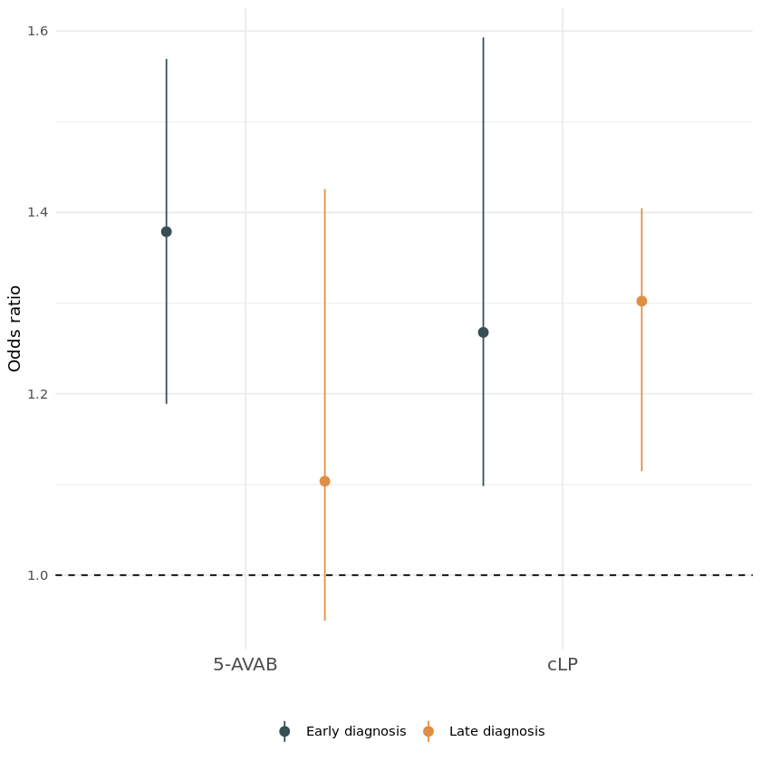

```r
p_strat
```

# Quartile analysis 5-AVAB

Perform analyses for 5-AVAB when divided into quartiles

```r
q_5AVAB <- cut(Data$"3376",c(-Inf,quantile(Data$"3376",c(0.25,0.5,0.75)),Inf),labels=c(1,2,3,4))
```

```r
output_q5AVAB <- glm(class~q_5AVAB+season_birth+age_at_sampling+gest
                   +as.factor(year)+scale(grs)
                   ,data=Data,family="binomial")
```

```r
plot_q5AVAB <- data.frame(c("Q1","Q2","Q3","Q4"))
colnames(plot_q5AVAB) <- "Quartile"
plot_q5AVAB$OR <- c(1,c(exp(coef(summary(output_q5AVAB))[2,1]),c(exp(coef(summary(output_q5AVAB))[3,1]),
                                                                       c(exp(coef(summary(output_q5AVAB))[4,1])))))
plot_q5AVAB$p <- c(1,coef(summary(output_q5AVAB))[2,4],coef(summary(output_q5AVAB))[3,4],
                   coef(summary(output_q5AVAB))[4,4])

plot_q5AVAB$low <- c(1,exp(confint.default(output_q5AVAB)[2]),exp(confint.default(output_q5AVAB)[3]),
                     exp(confint.default(output_q5AVAB)[4]))
plot_q5AVAB$high <- c(1,exp(confint.default(output_q5AVAB)[17]),exp(confint.default(output_q5AVAB)[18]),
                     exp(confint.default(output_q5AVAB)[19]))
```

```r
plot_q5AVAB
```

A data.frame: 4 × 5

| Quartile <chr> | OR <dbl> | p <dbl> | low <dbl> | high <dbl> |
| --- | --- | --- | --- | --- |
| Q1 | 1.0000000 | 1.0000000000 | 1.0000000 | 1.000000 |
| Q2 | 0.9118688 | 0.5398860688 | 0.6789217 | 1.224743 |
| Q3 | 1.1816353 | 0.2654277713 | 0.8808803 | 1.585076 |
| Q4 | 1.6902562 | 0.0005508967 | 1.2549539 | 2.276551 |

# cLP Present/absent

```r
output_cLP<- glm(class~factor(Data$"11694")+season_birth+age_at_sampling+gest
                   +as.factor(year)+scale(grs)
                   ,data=Data,family="binomial")
```

```r
plot_qcLP <- data.frame(c("Absent","Present"))
colnames(plot_qcLP) <- "Quartile"
plot_qcLP$OR <- c(1,c(exp(coef(summary(output_cLP))[2,1])))
plot_qcLP$p <- c(1,coef(summary(output_cLP))[2,4])

plot_qcLP$low <- c(1,exp(confint.default(output_cLP)[2]))
plot_qcLP$high <- c(1,exp(confint.default(output_cLP)[15]))
```

```r
plot_quartile <- rbind(plot_q5AVAB,plot_qcLP)
plot_quartile$metabolite <- c(rep("5-AVAB",4),rep("cLP",2))
```

```r
p_quartile <- ggplot(plot_quartile,aes(x=Quartile,y=OR,ymin=low,ymax=high,color=metabolite))+
geom_pointrange()+
theme_minimal()+
scale_color_jama()+
geom_hline(yintercept = 1,alpha=0.2)+
xlab("")+
ylab("Odds ratio")+
theme(legend.position = "bottom",legend.title = element_blank(),axis.text.x = element_text(size=10))
```

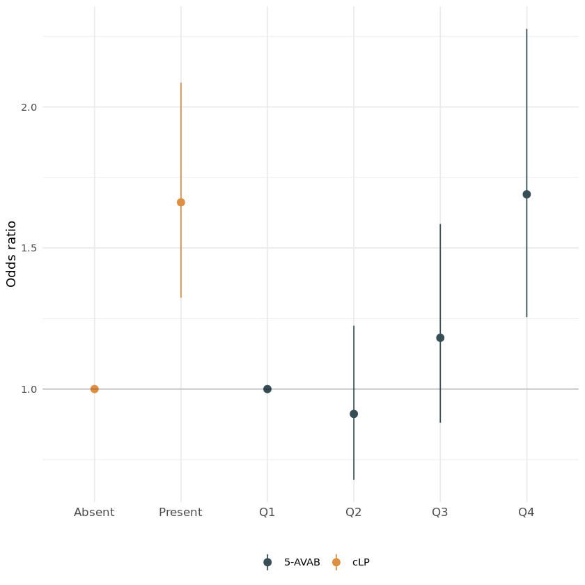

```r
p_quartile
```

**Figure 1** displays the volcano plot for model 1, quartile/present analyses for cLP and 5-AVAB and results for stratification for cLP and 5-AVAB.

```r
Fig1 <- plot_grid(p_logreg_nominal,plot_grid(p_quartile,p_strat,nrow=2,labels=c("B","C")),
                  ncol=2,rel_widths = c(1.4,1),labels=c("A",""))
```

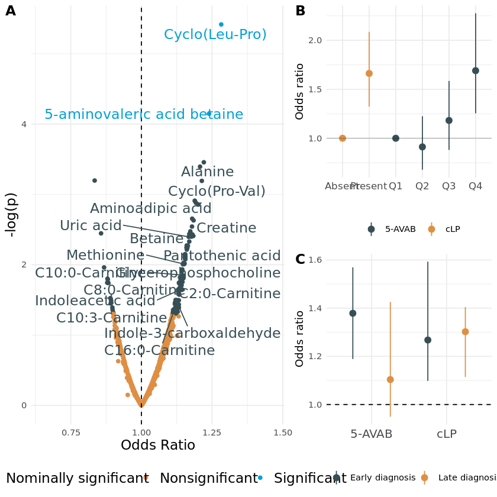

```r
Fig1
```

```r
ggsave(".../Figure_1.pdf",Fig1,
      height=7,width=10)
```

# Associations with GRS

We test whether the metabolites are related to genetic predisposition for autism by examining their association with the genetic risk score.

```r
linreg=NULL
for (i in 1:length(a)){
linreg[[i]] <- lm(scale(grs)~scale(Data[,a[i]])+season_birth+age_at_sampling+gest+as.factor(year)
                  +C1+C2+C3+C4+C5+C6
                   ,data=Data,subset=!is.na(C1))
    }
```

```r
output_linreg <- data.frame(names(Data)[start:ncol(Data)])
colnames(output_linreg) <- "Metabolite"
output_linreg$beta <- sapply(1:length(a),function(n){linreg[[n]]$coefficients[2]})
output_linreg$p <- sapply(1:length(a),function(n){summary(linreg[[n]])$coefficients[2,4]})
output_linreg$p_fdr <- p.adjust(output_linreg$p,method="fdr")
output_linreg$lowint <- sapply(1:length(a),function(n){confint.default((linreg[[n]]))[2]})
output_linreg$highint <- sapply(1:length(a),function(n){confint.default((linreg[[n]]))[14]})
output_linreg <- merge(output_linreg,annotations,by.x="Metabolite",by.y="id",all.x=TRUE)
output_linreg$significant <- ifelse(output_linreg$p_fdr<0.05,"Significant","Nonsignificant")
output_linreg["significant_nominal"] <- ifelse(output_linreg$p>0.05,"Nonsignificant",
                                               ifelse(output_linreg$p_fdr<0.05,"Significant",
                                                      "Nominally significant"))
```

```r
output_linreg %>% arrange(p) %>% head(n=10)
```

A data.frame: 10 × 10

|  | Metabolite <chr> | beta <dbl> | p <dbl> | p_fdr <dbl> | lowint <dbl> | highint <dbl> | annotation <chr> | Class <chr> | significant <chr> | significant_nominal <chr> |
| --- | --- | --- | --- | --- | --- | --- | --- | --- | --- | --- |
| 1 | 18406 | 0.07794284 | 0.008187149 | 0.987698 | 0.02026539 | -4.127610 | NA | NA | Nonsignificant | Nominally significant |
| 2 | 21061 | 0.07128315 | 0.008282894 | 0.987698 | 0.01845496 | -4.151413 | C16:0-Carnitine | Acyl carnitines | Nonsignificant | Nominally significant |
| 3 | 5168 | 0.07271448 | 0.009197440 | 0.987698 | 0.01808503 | -4.047041 | NA | NA | Nonsignificant | Nominally significant |
| 4 | 13689 | -0.06768013 | 0.013523111 | 0.987698 | -0.12131310 | -4.844977 | NA | NA | Nonsignificant | Nominally significant |
| 5 | 8846 | 0.06567279 | 0.015465433 | 0.987698 | 0.01258775 | -4.353854 | NA | NA | Nonsignificant | Nominally significant |
| 6 | 5925 | 0.06733127 | 0.017461383 | 0.987698 | 0.01188545 | -4.097715 |  | 0 | Nonsignificant | Nominally significant |
| 7 | 7502 | -0.06258079 | 0.019141485 | 0.987698 | -0.11486613 | -4.431025 |  | 0 | Nonsignificant | Nominally significant |
| 8 | 5128 | -0.06528124 | 0.021082188 | 0.987698 | -0.12068199 | -4.272333 |  | Aldehydes | Nonsignificant | Nominally significant |
| 9 | 1797 | -0.06171783 | 0.022428066 | 0.987698 | -0.11463412 | -4.070874 | NA | NA | Nonsignificant | Nominally significant |
| 10 | 22053 | -0.06537974 | 0.023681616 | 0.987698 | -0.12195182 | -3.958058 | NA | NA | Nonsignificant | Nominally significant |

```r
sum(output_linreg$p<0.05)
sum(output_linreg$p_fdr<0.05)
```

31

0

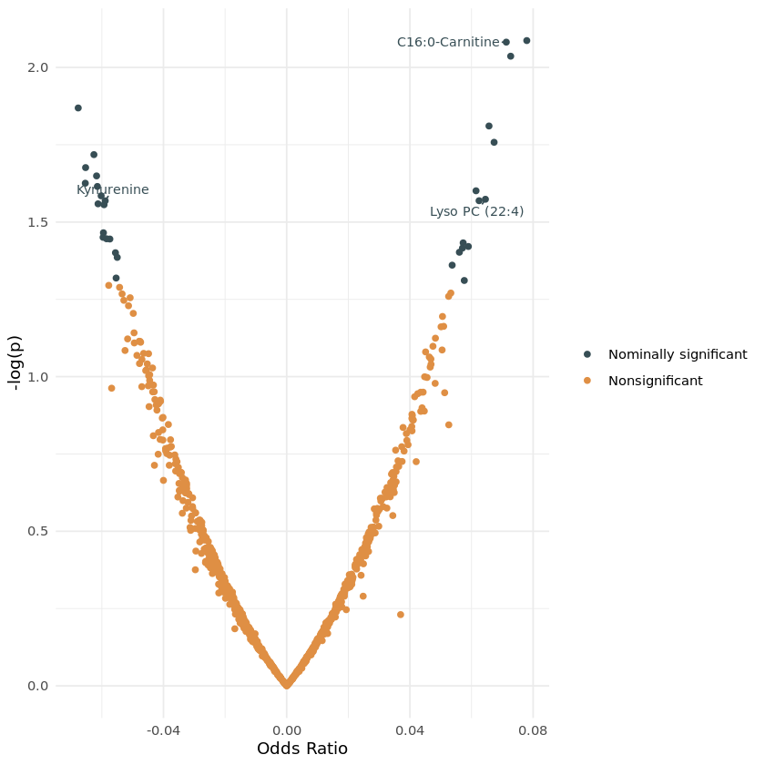

```r
p_linreg_grs <- ggplot(output_linreg,aes(x=beta,y=-log(p,base=10),color=significant_nominal))+
geom_point()+
theme_minimal()+
scale_color_jama()+
ylab("-log(p)")+
xlab("Odds Ratio")+
theme(legend.title = element_blank())+
geom_text_repel(data=subset(output_linreg,significant_nominal!="Nonsignificant" & annotation!=""),
                  aes(label=annotation),size=3,size=4,show.legend = FALSE,max.overlaps = Inf, force=1,force_pull=0,
                 min.segment.length = 0,max.time=10)

p_linreg_grs
```

```r
pdf(".../Figure_S1.pdf")
p_linreg_grs
dev.off()
```

**png:** 2

# Associations with family history of psychiatric disorders

Are metabolites associated with family history of psychiatric disorders?

```r
X <- Data[start:ncol(Data)]
logreg=NULL
a <- start:ncol(Data)
for (i in 1:length(a)){
logreg[[i]] <- glm(fam_hist~scale(Data[,a[i]])+season_birth+age_at_sampling+gest+as.factor(year)
                   ,data=Data,family="binomial")
    }
```

```r
output_logreg_fh <- cbind.data.frame(names(X))
colnames(output_logreg_fh)[1] <- "Metabolite"
output_logreg_fh["OR_logreg"]  <- sapply(1:length(a),function(n){exp(coef(summary(logreg[[n]]))[2,1])})
output_logreg_fh["logOR_logreg"]  <- sapply(1:length(a),function(n){coef(summary(logreg[[n]]))[2,1]})
output_logreg_fh["p_logreg"] <- sapply(1:length(a),function(n){coef(summary(logreg[[n]]))[2,4]})
output_logreg_fh["CI_low_logreg"] <- sapply(1:length(a),function(n){exp(confint.default(logreg[[n]]))[2]})
output_logreg_fh["CI_high_logreg"] <- sapply(1:length(a),function(n){exp(confint.default(logreg[[n]])[12])})
output_logreg_fh["p_fdr_logreg"] <- p.adjust(output_logreg_fh$p_logreg,method="fdr")
output_logreg_fh["p_bonf_logreg"] <- p.adjust(output_logreg_fh$p_logreg,method="bonferroni")
output_logreg_fh["significant_logreg"] <- ifelse(output_logreg_fh$p_fdr<0.05,"Significant","Nonsignificant")
output_logreg_fh <- merge(output_logreg_fh,annotations,by.x="Metabolite",by.y="id",all.x=TRUE)
output_logreg_fh["significant_nominal"] <- ifelse(output_logreg_fh$p_logreg>0.05,"Nonsignificant",
                                               ifelse(output_logreg_fh$p_fdr_logreg<0.05,"Significant",
                                                      "Nominally significant"))
```

```r
output_logreg_fh %>% arrange(p_logreg) %>% head(n=10)
```

A data.frame: 10 × 12

|  | Metabolite <chr> | OR_logreg <dbl> | logOR_logreg <dbl> | p_logreg <dbl> | CI_low_logreg <dbl> | CI_high_logreg <dbl> | p_fdr_logreg <dbl> | p_bonf_logreg <dbl> | significant_logreg <chr> | annotation <chr> | Class <chr> | significant_nominal <chr> |
| --- | --- | --- | --- | --- | --- | --- | --- | --- | --- | --- | --- | --- |
| 1 | 15284 | 0.7650293 | -0.2678411 | 7.664390e-06 | 0.6803368 | 0.6154172 | 0.004116545 | 0.006629697 | Significant |  | 0 | Significant |
| 2 | 3376 | 1.3029918 | 0.2646630 | 9.518023e-06 | 1.1589462 | 0.6710666 | 0.004116545 | 0.008233090 | Significant | 5-aminovaleric acid betaine | Acyl carnitines | Significant |
| 3 | 2668 | 0.7557081 | -0.2801001 | 4.644958e-05 | 0.6604109 | 0.6839927 | 0.013392961 | 0.040178883 | Significant | stachydrine | Amino acids and derivatives | Significant |
| 4 | 2765 | 0.7240722 | -0.3228641 | 8.814680e-05 | 0.6161603 | 0.6562603 | 0.019061745 | 0.076246978 | Significant |  | 0 | Significant |
| 5 | 1482 | 0.7733758 | -0.2569902 | 2.029667e-04 | 0.6753240 | 0.7144144 | 0.035113240 | 0.175566202 | Significant | Trimethyllysine | Amino acids and derivatives | Significant |
| 6 | 15308 | 0.7906608 | -0.2348863 | 3.140528e-04 | 0.6958335 | 0.6897864 | 0.041925609 | 0.271655693 | Significant |  | Amino acids and derivatives | Significant |
| 7 | 10622 | 0.7945277 | -0.2300074 | 3.877342e-04 | 0.6997332 | 0.6813868 | 0.041925609 | 0.335390119 | Significant | NA | NA | Significant |
| 8 | 13019 | 1.2321205 | 0.2087367 | 3.877513e-04 | 1.0979413 | 0.6888825 | 0.041925609 | 0.335404868 | Significant | C6:1-Carnitine | Acyl carnitines | Significant |
| 9 | 2774 | 0.7657651 | -0.2668798 | 5.859951e-04 | 0.6576883 | 0.6626041 | 0.050080475 | 0.506885787 | Nonsignificant | Ergothioneine | Amino acids and derivatives | Nominally significant |
| 10 | 607 | 0.8015108 | -0.2212568 | 6.120526e-04 | 0.7062214 | 0.6752449 | 0.050080475 | 0.529425507 | Nonsignificant | NA | NA | Nominally significant |

```r
sum(output_logreg_fh$p_logreg<0.05)
sum(output_logreg_fh$p_fdr_logreg<0.05)
```

127

8

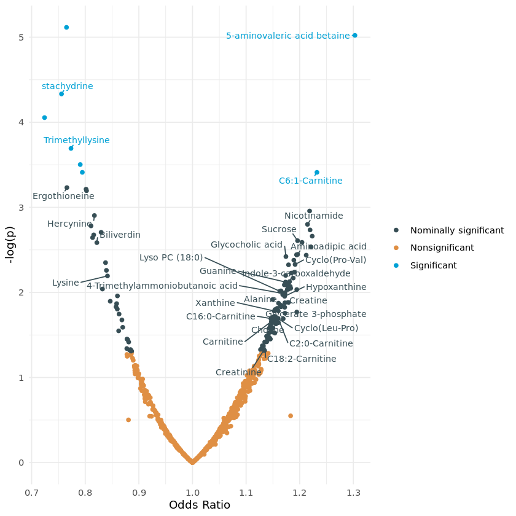

```r
p_logreg_FH <- ggplot(output_logreg_fh,aes(x=OR_logreg,y=-log(p_logreg,base=10),color=significant_nominal))+
geom_point()+
theme_minimal()+
scale_color_jama()+
ylab("-log(p)")+
xlab("Odds Ratio")+
theme(legend.title = element_blank())+
geom_text_repel(data=subset(output_logreg_fh,significant_nominal!="Nonsignificant" & annotation!=""),
                  aes(label=annotation),size=3,size=4,show.legend = FALSE,max.overlaps = Inf, force=1,force_pull=0,
                 min.segment.length = 0,max.time=10)

p_logreg_FH
```

```r
pdf(".../Figure_S2.pdf")
p_logreg_FH
dev.off()
```

**png:** 2

# Partial Correlations 5-AVAB

We investigate which metabolites are correlated with 5-AVAB. Partial correlations are computed.

```r
start <- which(names(Data)=="fu_aut")+1
X <- Data[start:ncol(Data)]
```

```r
which(names(X)=="3376")
```

134

```r
cor_mat <- pcor(scale(X))
```

```r
melted_cor <- melt(cor_mat$estimate)
melted_cor$Var1 <- rep(names(X),ncol(X))
melted_cor <- arrange(melted_cor,Var1)
melted_cor$Var2 <- rep(names(X),ncol(X))
```

```r
cor_AVAB <- cbind(data.frame(cor_mat$estimate[,134]),data.frame(cor_mat$p.value[,134]))
colnames(cor_AVAB) <- c("rho","pval")
```

```r
ACs <- subset(output_logreg,Class=="Acyl carnitines")$Metabolite
```

```r
melted_cor_AC <- melted_cor[melted_cor$Var1 %in% ACs & melted_cor$Var2 %in% ACs,]
```

```r
ACs <- annotations[annotations$id %in% unique(melted_cor_AC$Var1),] %>% arrange(id)
```

```r
network <- c("3376","2352","1870","3942","6650","8047","5673","9576","11448","14569","13019","16455","14033","19822","21061",
             "21966","21282","20604")

corplotdata_rho <- cor_mat$estimate[match(network,colnames(X)),match(network,colnames(X))]
corplotdata_p <- cor_mat$p.value[match(network,colnames(X)),match(network,colnames(X))]

colnames(corplotdata_rho) <- ACs[match(network,ACs$id),2]
rownames(corplotdata_rho) <- colnames(corplotdata_rho)
colnames(corplotdata_p) <- colnames(corplotdata_rho)
rownames(corplotdata_p) <- colnames(corplotdata_rho)
```

```r
#### Lower plot ####
get_lower_tri <- function(corplotdata_rho){
  corplotdata_rho[upper.tri(corplotdata_rho)] <- NA
return(corplotdata_rho)
}

get_lower_tri_p <- function(corplotdata_p){
  corplotdata_p[upper.tri(corplotdata_p)] <- NA
  return(corplotdata_p)
}

lower_cormat <- get_lower_tri(corplotdata_rho)
lower_cormat_p <- get_lower_tri(corplotdata_p)


corplotdata <- cbind.data.frame(melt(lower_cormat,na.rm = TRUE),
                               melt(lower_cormat_p,na.rm = TRUE)[3])
```

```r
colnames(corplotdata)[4] <- "pval"
corplotdata$significant <- ifelse(corplotdata$pval<0.05,"*","")
my_palette <- c("#374E55FF","#DF8F44FF")
```

```r
plot_cor_5AVAB <- ggplot(corplotdata,aes(x=Var1,y=Var2,fill=value))+
  geom_tile()+
  theme_minimal()+
  scale_fill_gradient2(low=my_palette[1],mid="white",high=my_palette[2],
                       limit = c(-0.3,1),
                       name=expression(paste("Partial\nSpearman's ",rho,sep=" ")))+
  theme(panel.background = element_rect(color="white"),
        axis.text.x = element_text(angle=45,vjust = 1,hjust = 1,size=14),
        axis.text.y = element_text(size=14),
        axis.title.x = element_blank(),
        axis.title.y = element_blank(),
        legend.title = element_text(size=16),
        legend.key.size = unit(0.75,"cm"))+
  geom_text(label=corplotdata$significant, size = 8)
```

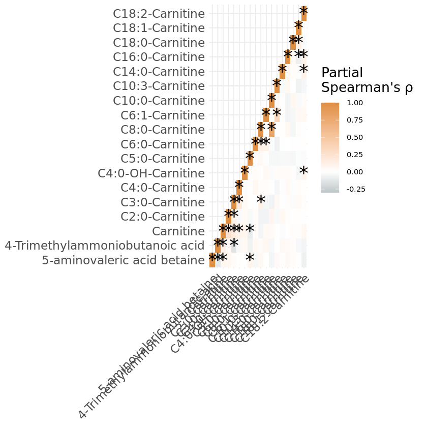

```r
plot_cor_5AVAB
```

# Partial correlations cyclo (LeuPro)

```r
which(names(X)=="11694")
```

751

```r
cor_cLP <- cbind(data.frame(cor_mat$estimate[,751]),data.frame(cor_mat$p.value[,751]),names(X))
colnames(cor_cLP) <- c("rho","pval","metabolites")
```

```r
cor_cLP %>% arrange(pval) %>% head(n=10)
```

A data.frame: 10 × 3

|  | rho <dbl> | pval <dbl> | metabolites <chr> |
| --- | --- | --- | --- |
| 1 | 1.0000000 | 0.000000e+00 | 11694 |
| 2 | 0.6886802 | 1.203282e-87 | 10017 |
| 3 | -0.1676991 | 2.915370e-05 | 8690 |
| 4 | -0.1257491 | 1.780811e-03 | 12814 |
| 5 | 0.1196295 | 2.964868e-03 | 7604 |
| 6 | 0.1168752 | 3.702376e-03 | 7634 |
| 7 | 0.1153115 | 4.191595e-03 | 6634 |
| 8 | -0.1125859 | 5.185920e-03 | 3365 |
| 9 | -0.1100195 | 6.311583e-03 | 4085 |
| 10 | 0.1099185 | 6.360067e-03 | 3839 |

```r
network <- cor_cLP[cor_cLP$pval<0.01,] %>% arrange(pval)
network <- network$metabolites
corplotdata_rho <- cor_mat$estimate[match(network,colnames(X)),match(network,colnames(X))]
corplotdata_p <- cor_mat$p.value[match(network,colnames(X)),match(network,colnames(X))]
```

```r
cLP_annotations <- merge(data.frame(network),output_logreg,by.x="network",by.y="Metabolite")[,c(1,10)]
cLP_annotations <- ifelse(is.na(cLP_annotations$annotation) | cLP_annotations$annotation=="",cLP_annotations$network,cLP_annotations$annotation)
```

```r
colnames(corplotdata_rho) <- cLP_annotations
rownames(corplotdata_rho) <- colnames(corplotdata_rho)
colnames(corplotdata_p) <- colnames(corplotdata_rho)
rownames(corplotdata_p) <- colnames(corplotdata_rho)
```

```r
#### Lower plot ####
get_lower_tri <- function(corplotdata_rho){
  corplotdata_rho[upper.tri(corplotdata_rho)] <- NA
return(corplotdata_rho)
}

get_lower_tri_p <- function(corplotdata_p){
  corplotdata_p[upper.tri(corplotdata_p)] <- NA
  return(corplotdata_p)
}

lower_cormat <- get_lower_tri(corplotdata_rho)
lower_cormat_p <- get_lower_tri(corplotdata_p)


corplotdata <- cbind.data.frame(melt(lower_cormat,na.rm = TRUE),
                               melt(lower_cormat_p,na.rm = TRUE)[3])
```

```r
colnames(corplotdata)[4] <- "pval"
corplotdata$significant <- ifelse(corplotdata$pval<0.05,"*","")
my_palette <- c("#374E55FF","#DF8F44FF")
```

```r
plot_cor_cLP <- ggplot(corplotdata,aes(x=Var1,y=Var2,fill=value))+
  geom_tile()+
  theme_minimal()+
  scale_fill_gradient2(low=my_palette[1],mid="white",high=my_palette[2],
                       limit = c(-0.3,1),
                       name=expression(paste("Partial\nSpearman's ",rho,sep=" ")))+
  theme(panel.background = element_rect(color="white"),
        axis.text.x = element_text(angle=45,vjust = 1,hjust = 1,size=14),
        axis.text.y = element_text(size=14),
        axis.title.x = element_blank(),
        axis.title.y = element_blank(),
        legend.title = element_text(size=16),
        legend.key.size = unit(0.75,"cm"))+
  geom_text(label=corplotdata$significant, size = 8)
```

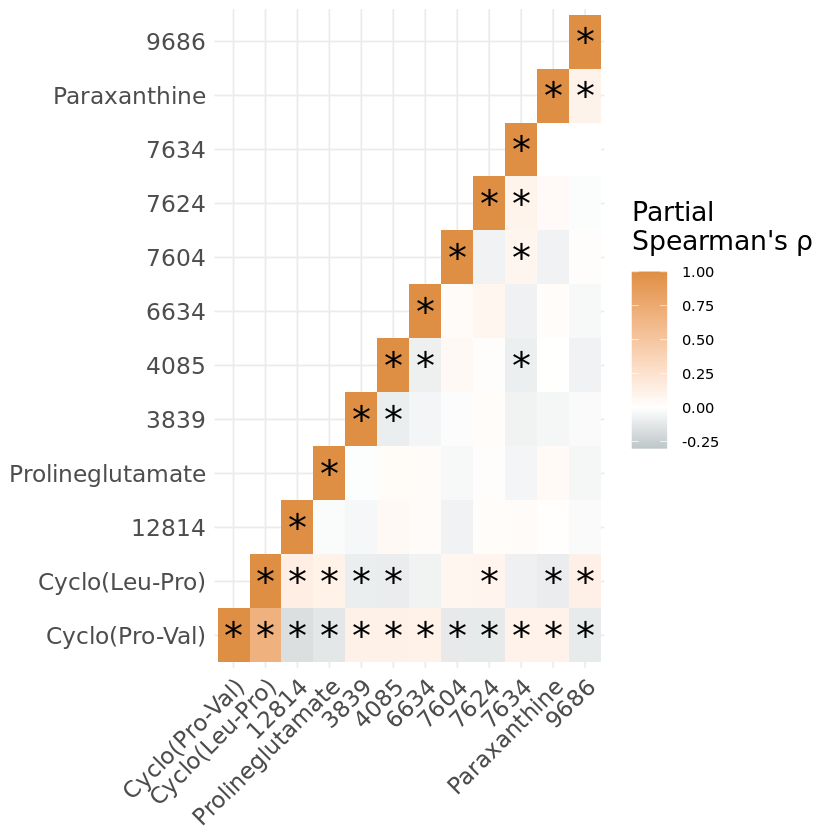

```r
plot_cor_cLP
```

```r
plot_ppcor <- plot_grid(plot_cor_cLP+theme(legend.position = "none"),plot_cor_5AVAB,ncol=2,
                        labels=c("A","B"),align = "h",rel_widths=c(1,1.5))
suppressWarnings(ggsave(".../Figure_2.pdf",plot_ppcor,
      height=10,width=20))
```

[output not shown]

# Class Enrichment

```r
output_logreg$Class[is.na(output_logreg$Class)] <- "Unknown"
output_logreg$Class[output_logreg$Class==0] <- "Unknown"
```

```r
enrich <- output_logreg %>% dplyr::select(Class,significant_nominal)
```

```r
enrich$significant_nominal[enrich$significant_nominal=="Significant"] <- 'Nominally significant'
```

```r
output=NULL
for (i in 1:nlevels(factor(enrich$Class))){
enrich$selected_class <- ifelse(enrich$Class==paste(levels(factor(enrich$Class))[i]),"AC","nonAC")
output[[i]] <- fisher.test(factor(enrich$significant_nominal),factor(enrich$selected_class))
    }
```

```r
fisher_out <- data.frame(levels(factor(enrich$Class)))
colnames(fisher_out) <- "Class"
```

```r
fisher_out <- data.frame(levels(factor(enrich$Class)))
colnames(fisher_out) <- "Class"
fisher_out$p <- sapply(1:nrow(fisher_out),function(n){output[[n]]$p.value})
fisher_out$p_fdr <- p.adjust(fisher_out$p,method="fdr")
```

```r
fisher_out %>% arrange(p) %>% head(n=10)
```

A data.frame: 10 × 3

|  | Class <chr> | p <dbl> | p_fdr <dbl> |
| --- | --- | --- | --- |
| 1 | Amino acids and derivatives | 0.008536004 | 0.2351296 |
| 2 | Acyl carnitines | 0.015067782 | 0.2351296 |
| 3 | Peptides | 0.016794970 | 0.2351296 |
| 4 | Benzoic acid esters | 0.114318707 | 0.6036478 |
| 5 | Indole-3-acetic acid derivatives | 0.114318707 | 0.6036478 |
| 6 | Organoheterocyclic compounds | 0.114318707 | 0.6036478 |
| 7 | Straight chain fatty acids | 0.114318707 | 0.6036478 |
| 8 | Unknown | 0.114980532 | 0.6036478 |
| 9 | Alkyl phosphates | 0.215685699 | 0.8235272 |
| 10 | Cholines | 0.215685699 | 0.8235272 |

```r
fisher_out$logp <- -log(fisher_out$p,base=10)
fisher_out$Significant <- ifelse(fisher_out$p<0.05,"Nominally Significant","Nonsignificant")
```

```r
p_class_enrichment <- ggplot(fisher_out,aes(x=logp,y=reorder(Class,logp),color=Significant))+
geom_point()+
theme_minimal()+
scale_color_jama()+
xlab("-log10(p)")+
ylab("Metabolite Class")+
theme(legend.title = element_blank())
```

```r
ggsave(".../enrichment_ASD.pdf",p_class_enrichment)
```

# Class enrichment FH

```r
output_logreg_fh$Class[is.na(output_logreg_fh$Class)] <- "Unknown"
output_logreg_fh$Class[output_logreg_fh$Class==0] <- "Unknown"
```

```r
enrich <- output_logreg_fh %>% dplyr::select(Class,significant_nominal)
```

```r
enrich$significant_nominal[enrich$significant_nominal=="Significant"] <- 'Nominally significant'
```

```r
output=NULL
for (i in 1:nlevels(factor(enrich$Class))){
enrich$selected_class <- ifelse(enrich$Class==paste(levels(factor(enrich$Class))[i]),"AC","nonAC")
output[[i]] <- fisher.test(factor(enrich$significant_nominal),factor(enrich$selected_class))
    }
```

```r
fisher_out <- data.frame(levels(factor(enrich$Class)))
colnames(fisher_out) <- "Class"
```

```r
fisher_out <- data.frame(levels(factor(enrich$Class)))
colnames(fisher_out) <- "Class"
fisher_out$p <- sapply(1:nrow(fisher_out),function(n){output[[n]]$p.value})
fisher_out$p_fdr <- p.adjust(fisher_out$p,method="fdr")
```

```r
fisher_out %>% arrange(p) %>% head(n=10)
```

A data.frame: 10 × 3

|  | Class <chr> | p <dbl> | p_fdr <dbl> |
| --- | --- | --- | --- |
| 1 | Amino acids and derivatives | 0.01292000 | 0.2832890 |
| 2 | Acyl carnitines | 0.01348995 | 0.2832890 |
| 3 | Peptides | 0.03317159 | 0.4644022 |
| 4 | Unknown | 0.08091433 | 0.8496004 |
| 5 | Benzoic acids | 0.14665127 | 0.8785774 |
| 6 | Bilirubins | 0.14665127 | 0.8785774 |
| 7 | Pyrimidine ribonucleoside | 0.14665127 | 0.8785774 |
| 8 | Xanthines | 0.21531368 | 0.8785774 |
| 9 | Bile acids and derivatives | 0.27194062 | 0.8785774 |
| 10 | Disaccharides | 0.27194062 | 0.8785774 |

```r
fisher_out$logp <- -log(fisher_out$p,base=10)
fisher_out$Significant <- ifelse(fisher_out$p<0.05,"Nominally Significant","Nonsignificant")
```

```r
p_class_enrichment_fh <- ggplot(fisher_out,aes(x=logp,y=reorder(Class,logp),color=Significant))+
geom_point()+
theme_minimal()+
scale_color_jama()+
xlab("-log10(p)")+
ylab("Metabolite Class")+
theme(legend.title = element_blank())
```

```r
ggsave(".../enrichment_FH.pdf",p_class_enrichment_fh)
```

# Interaction with age at diagnosis

```r
Data_early$early_onset <- rep(1,nrow(Data_early))
Data_late$early_onset <- rep(0,nrow(Data_late))
```

```r
Data <- rbind(Data_early,Data_late)
```

```r
summary(glm(class~scale(Data$"3376")+season_birth+age_at_sampling+gest
                   +as.factor(year)+scale(grs)+scale(Data$"3376")*Data$early_onset
                   ,data=Data,family="binomial"))
```

```
Call:
glm(formula = class ~ scale(Data$"3376") + season_birth + age_at_sampling +
    gest + as.factor(year) + scale(grs) + scale(Data$"3376") *
    Data$early_onset, family = "binomial", data = Data)

Deviance Residuals:
     Min        1Q    Median        3Q       Max
-1.78654  -1.14417  -0.08519   1.16018   1.76135

Coefficients:
                                      Estimate Std. Error z value Pr(>|z|)
(Intercept)                          0.1965955  1.7270502   0.114   0.9094
scale(Data$"3376")                   0.1001527  0.0760249   1.317   0.1877
season_birthspring                  -0.0308527  0.1485576  -0.208   0.8355
season_birthsummer                   0.0203161  0.1470619   0.138   0.8901
season_birthwinter                   0.0008644  0.1515602   0.006   0.9954
age_at_sampling                      0.0232872  0.0460885   0.505   0.6134
gest                                -0.0009841  0.0060763  -0.162   0.8713
as.factor(year)2004                 -0.0243676  0.1876531  -0.130   0.8967
as.factor(year)2005                 -0.0431242  0.1810593  -0.238   0.8117
as.factor(year)2006                 -0.0794656  0.1957331  -0.406   0.6848
as.factor(year)2007                 -0.0770064  0.1900446  -0.405   0.6853
as.factor(year)2008                 -0.0454219  0.1906140  -0.238   0.8117
scale(grs)                           0.2951409  0.0547948   5.386 7.19e-08 ***
Data$early_onset                    -0.0074802  0.1103773  -0.068   0.9460
scale(Data$"3376"):Data$early_onset  0.2337922  0.1089055   2.147   0.0318 *
---
Signif. codes:  0 ‘***’ 0.001 ‘**’ 0.01 ‘*’ 0.05 ‘.’ 0.1 ‘ ’ 1

(Dispersion parameter for binomial family taken to be 1)

    Null deviance: 2048.9  on 1477  degrees of freedom
Residual deviance: 1997.8  on 1463  degrees of freedom
AIC: 2027.8

Number of Fisher Scoring iterations: 4
```